# Projekt - Wstep do Analizy Danych

Maciej Ziętal

21 12 2020

# Wstep

Celem projektu jest porownanie zycia mieszkancow czterech najbogatszych regionow Wloch z pozostala czescia kraju. Analizowane regiony to

- Trentino Alto Adige
- Lombardia
- Emilia Romagna

Zostaly one wybrane na podstawie danych z Wikipedii z roku 2017. Warto zwrocic uwage na to, ze regiony South Tyrol i Trentino (kolejno 1 i 3 miejsce pod wzgledem PKB per capita), w wykorzystanych danych sa polaczone w jeden region - Trentino Alto Adige. Najwazniejsze w takim porownaniu moga byc nie wydatki na dobra podstawowe, a dobra wyzszego rzedu. Ich czestosc wystepowania w danym regionie, struktura, a takze to od czego zaleza.

## Hipotezy

- Ogolne wydatki w bogatszych regionach sa wyzsze i bardziej zroznicowane.
- Mieszkancy bogatszych regionow mieszkaja w bardziej luksusowych domach.
- Mieszkancy bogatszych regionow czesciej i wiecej wydaja na kulture.
- Wydatki mieszkancow bogatszych regionow na posilki poza domem sa wyzsze.
- Mieszkancy biedniejszych regionow czesciej decyduja sie na tansze alkohole.
- Mieszkancy bogatszych regionow chetniej podejmuja rozne aktywnosci i wydaja na nie wiecej.

# Analiza danych

## Wstepne informacje o posiadanych danych

Na poczatek warto przyjrzec sie jak wyglada rozklad typow rodzin w analizowanych regionach, a takze w pozostalej czesci kraju. Zgodnie z informacjami dotyczacymi danych wyrozniamy nastepujace typy rodzin:

- 1 - Osoba samotna w wieku poniżej 35 lat
- 2 - Osoba samotna w wieku 35-64 lat
- 3 - Osoba samotna w wieku 65 lat i starsza
- 4 - Para bez dzieci z osobą kontaktową poniżej 35 roku życia
- 5 - Para bez dzieci z osobą kontaktową w wieku 35-64 lat
- 6 - Para bez dzieci z osobą kontaktową w wieku 65 lat i starszą
- 7 - para z 1 dzieckiem
- 8 - para z 2 dziećmi
- 9 - para z 3 i więcej dziećmi
- 10 - samotny rodzic
- 11 - inne typy

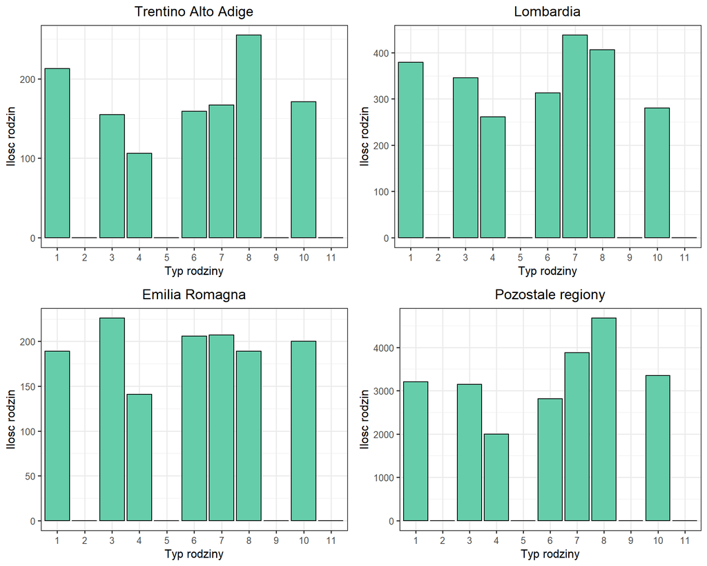

Warto zauwazyc, ze w badaniu nie braly udzialu zadne samotne osoby w wieku 35-64, pary bez dzieci z osoba kontaktowa w wieku 35-64, para z 3 lub wiecej dzieci (kolejno typ 2, 5, 9, 11). W regionie Trentino Alto Adige najwiecej jest par z dwojka dzieci, drugim najczestszym typem jest osoba samotna ponizej 35 roku zycia. Sytuacja wyglada zupelnie inaczej w regionach Lombardia i Emilia Romagna. W pierwszym z nich najczesciej spotykamy pare z jednym dzieckiem, na drugim miejscu pare z dwojgiem dzieci i osobe samotna ponizej 35 roku zycia. W Emilia Romagna natomiast mamy bardzo duzo osob samotnych, osob starszych powyzej 65 roku zycia, a takze mniej wiecej po rowno osob samotnych do 35 roku zycia, par z jednym i dwojka dzieci, par bez dzieci z osoba kontaktowa powyzej 65 roku zycia, a takze samotnych rodzicow. W pozostalej czesci Wloch najczesciej mozemy spotkac pary z dwojka oraz z jednym dzieckiem. Ciezko wyciagnac jakiekolwiek wnioski na podstawie tylko tych informacji, mozna jednak stwierdzic, ze w regionie Emilia Romagna mamy dosc sporo osob starszych. Moze to byc wiec region, do ktorego wyprowadzaja sie osoby na emeryturze, chcac odpoczac. Natomiast w regionach Trentino oraz Lombardii jest duzo osob mlodych, wiec moga byc to regiony, w ktorym mlodym osobom latwiej jest znalezc prace.

Warto wiec zobaczyc jak wyglada struktura wieku w kazdym z regionow.

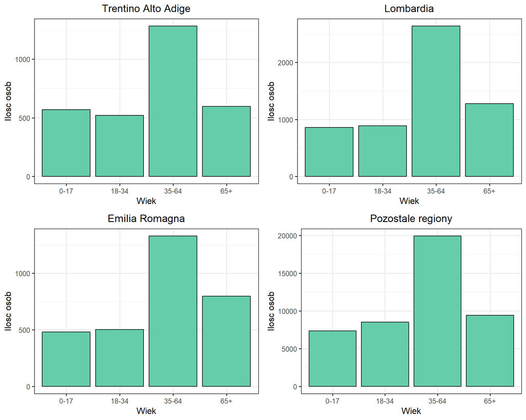

```r
DTrentino <- dane %>% filter(Regione == 4)
wiekTrentino <- c()
for (i in 1:nrow(DTrentino))
{
  if(!is.na(DTrentino$Eta4_1[i])) {wiekTrentino <- c(wiekTrentino, DTrentino$Eta4_1[i])}
  if(!is.na(DTrentino$Eta4_2[i])) {wiekTrentino <- c(wiekTrentino, DTrentino$Eta4_2[i])}
  if(!is.na(DTrentino$Eta4_3[i])) {wiekTrentino <- c(wiekTrentino, DTrentino$Eta4_3[i])}
  if(!is.na(DTrentino$Eta4_4[i])) {wiekTrentino <- c(wiekTrentino, DTrentino$Eta4_4[i])}
  if(!is.na(DTrentino$Eta4_5[i])) {wiekTrentino <- c(wiekTrentino, DTrentino$Eta4_5[i])}
  if(!is.na(DTrentino$Eta4_6[i])) {wiekTrentino <- c(wiekTrentino, DTrentino$Eta4_6[i])}
}

wiekTr <- as.data.frame(table(wiekTrentino))
wiekTr <- wiekTr %>%
  mutate(wiek = ifelse(wiekTrentino == 1, "0-17",
                       ifelse(wiekTrentino == 2, "18-34",
                              ifelse(wiekTrentino == 3, "35-64", "65+"))))

p1 <- ggplot() +
  geom_col(data = wiekTr, mapping = aes(x = wiek, y = Freq),
           fill = "aquamarine3", color = "black") +
  theme_bw(base_size = 12) +
  labs(title="Trentino Alto Adige", x = "Wiek", y = "Ilosc osob") +
  theme(plot.title = element_text(hjust = 0.5))
```

Jak widac na powyzszych wykresach, najwiekszy udzial w spoleczenstwie maja osoby pomiedzy 35 a 64 rokiem zycia. Pozostale zakresy sa rozne w zaleznosci od regionu. W Trentino Alto Adige slupki obrazujace ilosc osob ponizej 18 roku zycia oraz miedzy 18 a 34 rokiem zycia sa zblizone wysokoscia do osob powyzej 65 roku zycia. W pozostalych regionach ta roznica jest zdecydowanie wieksza. W przypadku regionu Emilia Romagna widac znaczny udzial osob starszych w spoleczenstwie. Natomiast Lombardia jest najbardziej zblizona rozkladem do pozostalej czesci Wloch.

## Roznice w wysokosci wydatkow

Jednym z glownych czynnikow, od ktorych zalezy styl zycia sa dochody rodzin(w tym przypadku laczne wydatki).

```r
dane <- dane %>%
  mutate(Wydatki = (C_3101+C_3102+C_3401+C_3402+C_9301+C_3403+C_3404+C_3405+C_3406+C_3407+C_3201+
                      C_3203+C_3204+C_3205+C_3207+C_3208+C_3209+C_3210+C_3211+C_3212+C_3121+C_3123+
                      C_3421+C_3422+C_9321+C_3423+C_3424+C_3425+C_3426+C_3321+C_3427+C_3221+C_3223+
                      C_3224+C_3225+C_3227+C_3228+C_3229+C_3230+C_3231+C_3232+C_4301+C_4302+C_4303+
                      C_4304+C_4305+C_4306+C_4307+C_4308+C_4309+C_4101+C_4102+C_4104+C_4201+C_4105+
                      C_4106+C_4107+C_4501+C_4310+C_4401+C_4402+C_4403+C_4311+C_4601+C_4602+C_4607+
                      C_2101+C_2102+C_2103+C_2104+C_2105+C_2106+C_2107+C_2108+C_2201+C_2202+C_2203+
                      C_5301+C_5302+C_5303+C_5201+C_5202+C_5203+C_5204+C_5205+C_5101+C_5102+C_5103+
                      C_5104+C_6101n+C_6101u+C_6102n+C_6102u+C_6103n+C_6104u+C_6104n+C_6104u+C_6105n+C_6105u
                    +C_6201+C_6203+C_6204+C_6205+C_6206+C_6301+C_6302+C_6303+C_6304+C_7130+C_7131
                    +C_7132+C_7133+C_7101+C_7102+C_7104+C_7107+C_7109+C_7105+C_7110+C_7201+C_7202
                    +C_7111+C_7103+C_7203+C_7113+C_7114+C_7115+C_7301+C_8101+C_8102+C_8103+C_8201
                    +C_8104+C_8105+C_9901+C_9902+C_9903+C_9911+C_9912+C_9913+C_9201+C_9202+C_9203
                    +C_9204+C_9205+C_9103+C_9297+C_5401+C_3302+C_3322+C_6207+C_6208+C_7205+C_9403
                    +C_9404+C_9405+C_6305+C_9497+C_9401+C_9411+C_9412+C_9413+C_1101+C_1102+C_1103
                    +C_1104+C_1105+C_1106+C_1701+C_1702+C_1703+C_1107+C_1801+C_1802+C_1704+C_1705
                    +C_1201+C_1202+C_1203+C_1204+C_1205+C_1206+C_1207+C_1208+C_1209+C_1297+C_1301
                    +C_1302+C_1303+C_1304+C_1501+C_1502+C_1503+C_1504+C_1505+C_1401+C_1402+C_1403
                    +C_1404+C_1405+C_1406+C_1621+C_1622+C_1631+C_1623+C_1624+C_1625+C_1627+C_1601
                    +C_1602+C_1603+C_1604+C_1605+C_1606+C_1607+C_1608+C_1609+C_1803+C_1804+C_1805
                    +C_1806+C_1807+C_1808+C_9801+C_9802+C_9803+C_1901+C_2109+C_4503+C_4404+C_4603
                    +C_4604+C_4605+C_4502+C_4697+C_9101+C_9102+C_9104+C_7302+C_7303+C_7304+C_9306
                    +C_9307+C_6209+C_6210+C_6306+C_6307+C_6211+C_5105+C_5106+C_5107+C_7116+C_7117
                    +C_7118+C_7119+C_7197+C_7120+C_7206+C_7207+C_7208+C_7297+C_4606+C_2204+C_2110
                    +C_4108+C_4312+C_4313+C_7121+C_4202+C_7134+C_9804)/NC)


daneWydatki <- dane %>%
  filter(Wydatki >quantile(dane$Wydatki, 0.005) & Wydatki < quantile(dane$Wydatki, 0.995))

biedniejsze <- daneWydatki %>%
  filter(Regione != 3 & Regione != 4 & Regione != 8)

d4 <- as.data.frame(biedniejsze$Wydatki)
d4 <- d4 %>%
  mutate(region = "Pozostale")
colnames(d4) <- c("wydatki", "region")
```

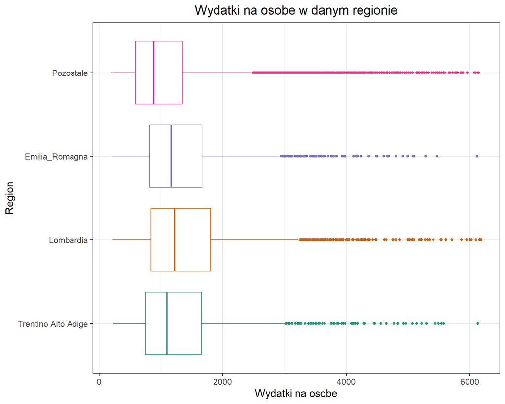

```r
danePudelkowy1 <- rbind(d1,d2,d3,d4)
danePudelkowy1$region <- factor(danePudelkowy1$region, levels=c("Trentino Alto Adige", "Lombardia", "Emilia_Romagna", "Pozostale"), ordered=TRUE)

ggplot(danePudelkowy1, mapping = aes(y=region, x = wydatki)) +
  geom_boxplot(col = brewer.pal(n=4, name="Dark2")) +
  theme_bw(base_size = 15) +
  labs(title = "Wydatki na osobe w danym regionie", x = "Wydatki na osobe", y = "Region") +
  theme(plot.title = element_text(hjust = 0.5), legend.position = "none")
```

Na powyzszym wykresie widac, ze srednio najwiecej wydaja mieszkancy regionow Lombardia, nastepnie Emilia Romagna oraz Trentino. Znaczaco mniejsze wydatki sa w pozostalej czesci Wloch, mediana jest tam nizsza od 1000 euro i jest w przyblizeniu rowna dolnemu kwartylowi w Lombardii. Mozna takze zauwazyc, ze samo pudelko w przypadu pozostalej czesci Wloch jest dosc waskie. Natomiast w Lombardii jest zdecydowanie szersze, a roznica miedzy dolnym a gornym kwartylem wynosi okolo 1000 euro. Oznacza to dosc spore roznice w wydatkach gospodarstw. Warto takze zwrocic uwage na wartosci odstajace. W kazdym z regionow jest ich dosc sporo, co dosc naturalne, najwiecej w przypadku pozostalej czesci Wloch. Stamtad pochodzi najwiecej danych, a co za tym idzie, najprawdopodobniej znajdziemy tam tez duzo “bogaczy”, ktorzy wydaja wiecej od pozostalych. W przypadku Lombardii mamy duza ilosc bardzo wysokich wartosci odstajacych, zdecydowanie wiecej niz w Emilia Romagna, czy Trentino. Jest wiec dosc prawdopodobne, ze mieszka tam sporo bardzo bogatych osob.

```r
Region<-c("Trentino Alto Adige", "Lombardia", "Emilia Romagna", "Pozostale Regiony")
SredniaWydatkow<-c(mean(d1$wydatki), mean(d2$wydatki), mean(d3$wydatki), mean(d4$wydatki))
data.frame(Region,SredniaWydatkow)
```

```
##                Region SredniaWydatkow
## 1 Trentino Alto Adige        1354.539
## 2           Lombardia        1469.875
## 3      Emilia Romagna        1370.598
## 4   Pozostale Regiony        1092.602
```

Mozemy takze zwrocic uwage na srednie wydatki. Mozna z nich wyciagnac podobne wnioski, jak z powyzszych wykresow pudelkowych. Najwiecej wydaja mieszkancy Lombardii, nastepnie sporo mniej Emilii Romagni, potem niewiele mniej mieszkancy Trentino, a znaczaco mniej mieszkancy pozostalej czesci Wloch.

## Zamieszkiwane domy

Jednym z wyznacznikow statusu spolecznego i posiadanego majatku jest dom, w ktorym sie mieszka. W danych wyrozniane jest 5 rodzajow domow:

- Villa o Villino - Wille, o cechach wyzszego poziomu, znajdujace sie w prestizowych okolicach, z ogrodami i parkami
- Signorile - budynek polozony na prestizowych terenach, o cechach wyzszego poziomu niz normalne budynki
- Civile, Economica e Popolare - najczestszy typ mieszkania, o cechach sredniego poziomu
- Rurale - mieszkania wiejskie
- Improria - pozostale domy

Ich rozklad mozna w spoleczenstwie mozna zaprezentowac w nastepujacy sposob.

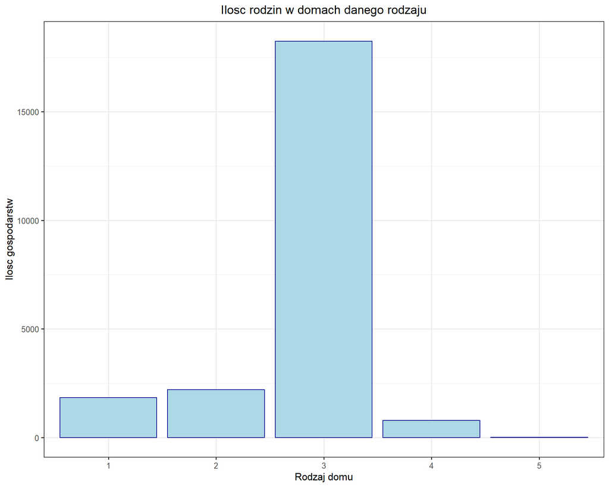

```r
rodzajeDomow <- as.data.frame(table(dane$TipoA))

ggplot() +
  geom_col(rodzajeDomow, mapping = aes(y=Freq, x =Var1),
           fill = "lightblue", color = "darkblue") +
  theme_bw(base_size = 12) +
  labs(title = "Ilosc rodzin w domach danego rodzaju", x = "Rodzaj domu", y = "Ilosc gospodarstw") +
  theme(plot.title = element_text(hjust = 0.5))
```

Badany rozklad, jest takze inny dla kazdego regionu, co obrazuja ponizsze wykresy.

```r
Lombardia <- dane %>%
  filter(Regione == 3)

rodzajeDomowLombardia <- as.data.frame(table(Lombardia$TipoA))
rodzajeDomowLombardia <- rodzajeDomowLombardia %>%
  add_row(Var1 = "5", Freq = 0)

p2 <- ggplot() +
  geom_col(rodzajeDomowLombardia, mapping = aes(y=Freq, x =Var1),
           fill = "lightblue", color = "darkblue") +
  theme_bw(base_size = 12) +
  labs(title = "Lombardia", x = "Rodzaj domu", y = "Ilosc gospodarstw") +
  theme(plot.title = element_text(hjust = 0.5))
```

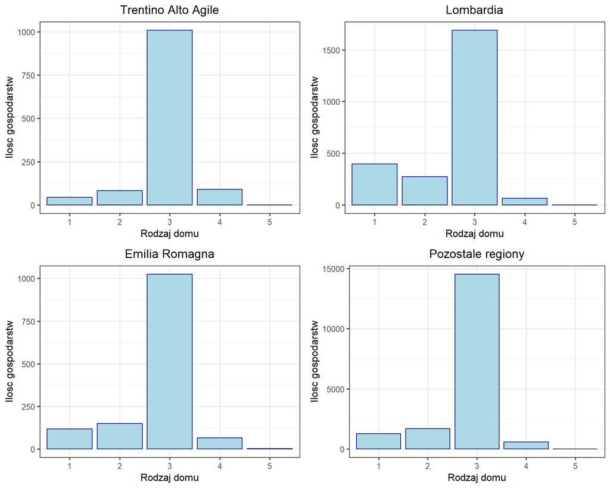

```r
ggarrange(p1,p2,p3,p4)
```

W kazdym z regionow jest znaczaca przewaga domow 3 typu. Jednak w Lombardii czy Emilia Romagna jest takze sporo domow luksusowych (typ 1 i typ 2). Ich procentowy udzial w domach w danym regionie obrazuje ponizszy wykres.

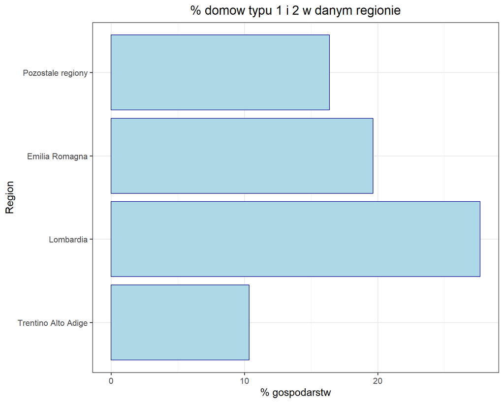

Widac tu wyraznie dosc znaczaca przewage Lombardii, gdzie blisko 30% rodzin mieszka w luksusowych domach. W regionie Emilia Romagna okolo 20% rodzin mieszka w takich domach. Bardzo malo, bo niewiele ponad 10% gospodarstw w Trentino Alto Adige stanowia luksusowe domy. Jest to dosc zaskakujace, gdyz jest to region z najwyzszym PKB per capita w calym kraju. W pozostalej czesci Wloch udzial domow o wyzszym standardzie wynosi okolo 17%.

## Wydatki na kulture

Wydatki na kulture nie sa wydatkami pierwszej potrzeby, mozna wrecz powiedziec, ze sa na samym koncu wsrod wydatkow i decydujemy sie na nie, gdy wszystkie nasze potrzeby sa zapewnione. Dlatego stanowia one wazny element tej analizy. Dzieki porownaniu tych wydatkow, bedzie mozna poznac wazna skladowa, ktora moze odrozniac mieszkancow bogatszych regionow od tych z biedniejszej czesci Wloch.

```r
daneKultura <- dane %>%
  mutate(SumaWydatkowKultura = (C_7301+ C_7204)/NC)

daneKulturabez0 <- daneKultura %>%
  filter(SumaWydatkowKultura >0)

Lombardia <- daneKultura %>%
  filter(Regione == 3)

Lombardia_bez0 <- Lombardia %>%
  filter(SumaWydatkowKultura > 0)

Lombardia_procentOsobWydatkiKultura <- as.numeric(count(Lombardia_bez0)/count(Lombardia)*100)
```

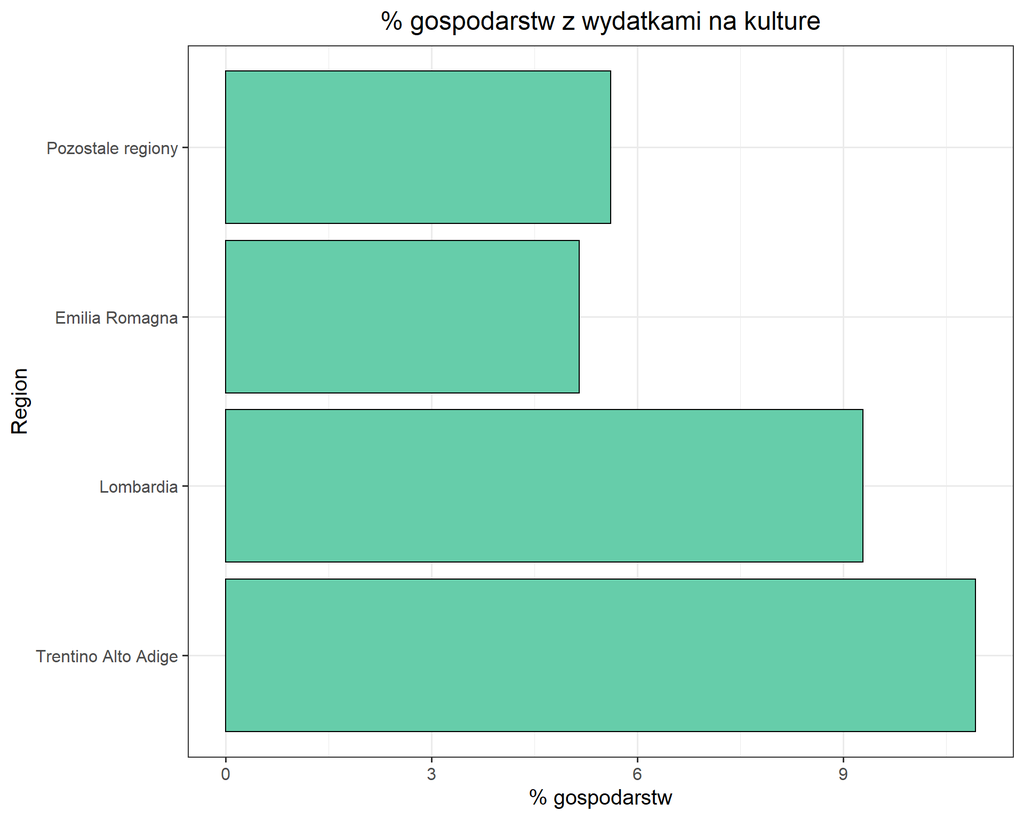

```r
procentWydatkowKultura <- data.frame(region = c("Trentino Alto Adige", "Lombardia", "Emilia Romagna", "Pozostale regiony"), procKultura = c(Trentino_procentOsoWydatkiKultura, Lombardia_procentOsobWydatkiKultura, Emilia_procentowoOsobWydatkiKultura, biedniejsze_procentowoOsobWydatkiKultura))

procentWydatkowKultura$region <- factor(procentWydatkowKultura$region, levels = c("Trentino Alto Adige", "Lombardia", "Emilia Romagna", "Pozostale regiony"), ordered=TRUE)

ggplot(procentWydatkowKultura, aes(x=procKultura, y=region)) +
  geom_col(fill = "aquamarine3", color = "black") +
  theme_bw(base_size = 15) +
  labs(title = "% gospodarstw z wydatkami na kulture", x = "% gospodarstw", y = "Region") +
  theme(plot.title = element_text(hjust = 0.5))
```

Na powyzszym wykresie mozemy zobaczyc, w ktorym regionie najwiekszy % gospodarstw odnotowal wydatki na kulture w badanym okresie. Najwyzszy procent jest w Trentino Alto Adige i wynosi okolo 10-11%. Niewiele ponad 9% gospodarstw odnotowalo takie wydatki w Lombardii. Odsetek ten jest natomiast zdecydowanie nizszy w Emilia Romagna oraz pozostalych regionach kraju, gdzie wynosi zaledwie okolo 5-6%.

Warto takze przyjrzec sie samym wydatkom, w tym celu musimy posluzyc sie danymi bez gospodarstw, ktore nie odnotowaly wydatkow na kulture. Dodatkowo nalezy pozbyc sie wartosci odstajacych, ktore moga zaburzac nasze dane.

```r
daneKulturabez0 <- daneKultura %>%
  filter(SumaWydatkowKultura >0)

daneKulturabez0 <- daneKulturabez0 %>%
  filter(SumaWydatkowKultura < quantile(SumaWydatkowKultura, 0.97))

biedniejsze_bezOdstajacych <- daneKulturabez0 %>%
  filter(Regione != 3 & Regione != 4 & Regione != 8)

x4 <- as.data.frame(biedniejsze_bezOdstajacych$SumaWydatkowKultura)
x4 <- x4 %>%
  mutate(region = "Pozostale regiony")
colnames(x4) <- c("wydatki", "region")
```

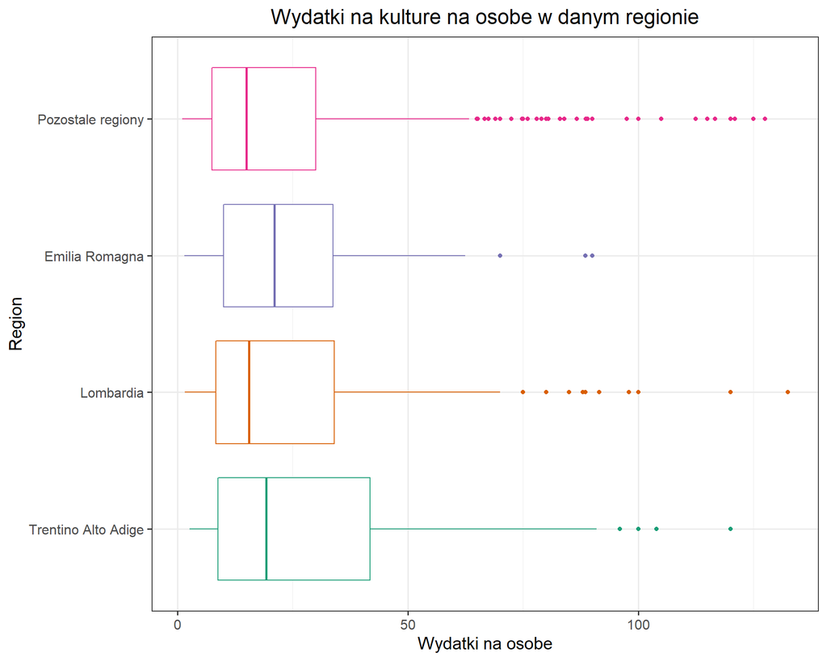

```r
danePudelkowy <- rbind(x1, x2, x3, x4)
danePudelkowy$region <- factor(danePudelkowy$region, levels=c("Trentino Alto Adige", "Lombardia", "Emilia Romagna", "Pozostale regiony"), ordered=TRUE)

ggplot(danePudelkowy, mapping = aes(y=region, x = wydatki)) +
  geom_boxplot(col = brewer.pal(n=4, name="Dark2")) +
  theme_bw(base_size = 15) +
  labs(title = "Wydatki na kulture na osobe w danym regionie", x = "Wydatki na osobe", y = "Region") +
  theme(plot.title = element_text(hjust = 0.5), legend.position = "none")
```

Jak widac na powyzszych wykresach pudelkowych z wasem, najwyzsza mediana wydatkow jest w regionach Emilia Romagna oraz Trentino Alto Adige, natomiast nieco nizsza jest w Lombardii i pozostalej czesci Wloch. Warto jednak zauwazyc dosc duze pudelko w regionie Trentino, gorny kwartyl jest polozony bardzo wysoko, w porownaniu do pozostalych reginow, gdzie pudelka sa dosc zblizone do siebie pod wzgledem wielkosci. Nalezy takze zwrocic uwage na wartosci odstajace, ktore sa bardzo liczne w przypadku pozostalej czesci Wloch, co jest dosc naturalne, jednak wiekszosc z nich nie jest bardzo wysoka i porowywalna z koncowka wasa w przypadku Trentino Alto Adige. Podstawowym nasuwajacym sie wnioskiem jest to, ze w regionie Trentino jest duzy rozstrzal w wydatkach na kulure, zdecydowanie wyzszy niz w pozostalych regionach. Dosc sporo wartosci odstajacych jest takze w Lombardii, jednak wiecej ludzi wydaje raczej niewiele, o czym swiadczy niska mediana. W regionie Emilia Romagna wydatki na kulture sa na dosc wysokim, ale zblizonym do siebie poziomie wsrod wszystkich ludzi. W pozostalej czesci Wloch wydatki sa raczej niskie, niezbyt rozniace sie od siebie, poza stosunkowo nie licznymi wartosciami odstajacymi.

Powyzsze rozwazania zostaly takze sprawdzone, za pomoca regresji logistycznej.

```r
daneKultura <- dane %>%
  mutate(SumaWydatkowKultura = (C_7301+ C_7204)/NC)

daneKultura <- daneKultura %>%
  filter(SumaWydatkowKultura < quantile(SumaWydatkowKultura, 0.999))

daneKultura <- daneKultura %>%
  mutate(CzyMaWydatki = ifelse(SumaWydatkowKultura > 0, 1, 0))

daneKultura <- daneKultura%>%
  mutate(KtoryRegion = ifelse(Regione != 3 & Regione != 4 & Regione != 8, "A_Pozostale",
                              ifelse(Regione == 4, "B_Trentino",
                                     ifelse(Regione == 3, "C_Lombardia", "D_Emilia"))))


daneKultura$KtoryRegion <- as.factor(daneKultura$KtoryRegion)
glm.fit <- glm(CzyMaWydatki ~ Wydatki + KtoryRegion, data = daneKultura, family = binomial)

summary(glm.fit)
```

```
##
## Call:
## glm(formula = CzyMaWydatki ~ Wydatki + KtoryRegion, family = binomial,
##     data = daneKultura)
##
## Deviance Residuals:
##     Min       1Q   Median       3Q      Max
## -3.6806  -0.3573  -0.3264  -0.3130   2.5434
##
## Coefficients:
##                          Estimate Std. Error z value Pr(>|z|)
## (Intercept)            -3.115e+00  4.221e-02 -73.797  < 2e-16 ***
## Wydatki                 2.288e-04  2.024e-05  11.303  < 2e-16 ***
## KtoryRegionB_Trentino   6.372e-01  9.917e-02   6.425 1.32e-10 ***
## KtoryRegionC_Lombardia  4.248e-01  7.914e-02   5.367 7.98e-08 ***
## KtoryRegionD_Emilia    -1.880e-01  1.294e-01  -1.453    0.146
## ---
## Signif. codes:  0 '***' 0.001 '**' 0.01 '*' 0.05 '.' 0.1 ' ' 1
##
## (Dispersion parameter for binomial family taken to be 1)
##
##     Null deviance: 10649  on 23047  degrees of freedom
## Residual deviance: 10449  on 23043  degrees of freedom
## AIC: 10459
##
## Number of Fisher Scoring iterations: 5
```

```r
coef(glm.fit)
```

```
##            (Intercept)                Wydatki  KtoryRegionB_Trentino
##          -3.1147784846           0.0002287648           0.6372238843
## KtoryRegionC_Lombardia    KtoryRegionD_Emilia
##           0.4247804303          -0.1880118366
```

## Wydatki na posilki poza domem

We Wloszech ludzie bardzo czesto decyduja sie na jedzenie posilku poza domem. Jest to elementem ich kultury. Warto jednak zobaczyc, czy czestosc, a takze wysokosc wydatkow na takie posilki zaleza od regionu zamieszkania. Na poczatek jednak nalezy sprawdzic, czy jest to jak sie wydaje, dobro podstawowe, czy moze jednak bardziej luksusowe.

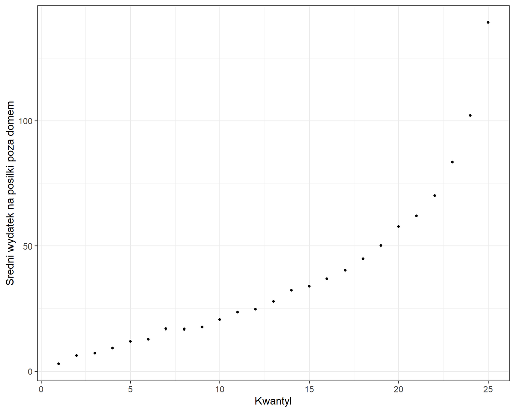

```r
danePozaDomem <- dane %>%
  mutate(SumaPozaDomem = (C_9801+C_9802+C_9803)/NC)

danePozaDomem <- danePozaDomem %>%
  mutate(quantile = ntile(Wydatki, 25))

danePozaDomemBez25 <- danePozaDomem %>%
  filter(quantile!= 25 & quantile!=1)

sredniePozaDomem <- c()

for (i in 1:25) {
  sr <- danePozaDomem %>%
    filter(quantile == i)
  sredniePozaDomem[i] <- mean(sr$SumaPozaDomem)
}

srednieWydatki <- c()
for (i in 1:25) {
  sr <- danePozaDomem %>%
    filter(quantile == i)
  srednieWydatki[i] <- mean(sr$Wydatki)
}

kwantyle <- danePozaDomem$quantile[!duplicated(danePozaDomem$quantile)]

kwantyle <- sort(kwantyle)

ggplot() +
  geom_point(mapping=aes(x=kwantyle, y = sredniePozaDomem)) +
  labs(x="Kwantyl", y = "Sredni wydatek na posilki poza domem") +
  theme_bw(base_size = 15)
```

Na powyzszym wykresie, widac, ze wraz ze wzrostem srednich wydatkow coraz szybciej rosna wydatki na dane dobro, co jest cecha charakterystyczna dla dobr luksusowych. Jest to dosc zaskakujace, bo wedlug utartych przekonan, spozywanie posilkow poza domem jest we Wloszech rzecza naturalna, a nie oznaka luksusu.

```r
m <- nls(SumaPozaDomem ~ A*Wydatki*(Wydatki - C)/(B + Wydatki), data = danePozaDomemBez25,
         start = list(A = 3, B = 3, C = 200))
summary(m)
```

```
##
## Formula: SumaPozaDomem ~ A * Wydatki * (Wydatki - C)/(B + Wydatki)
##
## Parameters:
##    Estimate Std. Error t value Pr(>|t|)
## A 4.466e-02  1.562e-03  28.589  < 2e-16 ***
## B 1.078e+02  1.385e+02   0.778 0.436378
## C 2.335e+02  6.659e+01   3.507 0.000455 ***
## ---
## Signif. codes:  0 '***' 0.001 '**' 0.01 '*' 0.05 '.' 0.1 ' ' 1
##
## Residual standard error: 56.33 on 21226 degrees of freedom
##
## Number of iterations to convergence: 7
## Achieved convergence tolerance: 3.895e-06
```

Na podstawie wzoru funkcji Tornquista dla dobr luksusowych
$$Y = \frac{aX(X-c)}{b+X}$$
gdzie Y to wydatki na analizowane dobro, a X to przychody gospodarstwa, tworzymy model, ktory przyblizy nam funkcje wydatkow na to dobro. Parametry W przypadku parametrow A i C wartosci p-value sa bardzo niskie, co swiadczy o dobrym dopasowaniu modelu. W przypadku parametru B wartosc ta nie jest statystycznie istotna.

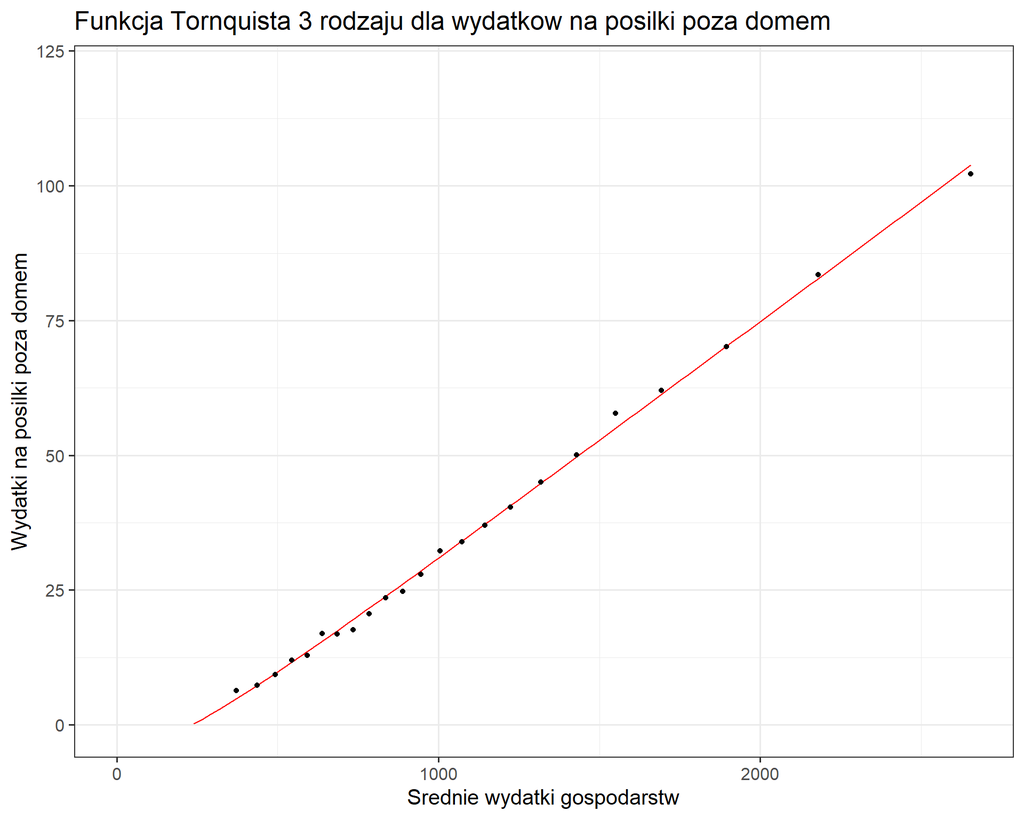

```r
A1 <- as.numeric(coef(m)[1])
B1 <- as.numeric(coef(m)[2])
C1 <- as.numeric(coef(m)[3])

sredniePozaDomem <- sredniePozaDomem[-c(1,25)]
srednieWydatki <- srednieWydatki[-c(1,25)]

eq = function(x){A1 * x * (x - C1)/(B1 + x)}

ggplot() + stat_function(fun = eq, data.frame(x=c(1,2000)), mapping=aes(x=x), col= "red") +
  geom_point(mapping=aes(srednieWydatki,sredniePozaDomem)) +
  ylim(0,120) +
  theme_bw(base_size = 15) +
  labs(title = "Funkcja Tornquista 3 rodzaju dla wydatkow na posilki poza domem",
       x = "Srednie wydatki gospodarstw", y = "Wydatki na posilki poza domem")
```

Wykres prezentuje funkcje Tornquista 3 rodzaju, dla dobr luksusowych, jest ona dosc dobrze dopasowana. Dzieki wyestymowanym parametrom mozna zobaczyc jak prezentuja sie elastycznosci w analizowanych regionach.

```r
daneWydatki <- dane %>%
  filter(Wydatki >quantile(dane$Wydatki, 0.005) & Wydatki < quantile(dane$Wydatki, 0.995))

biedniejsze <- daneWydatki %>%
  filter(Regione != 3 & Regione != 4 & Regione != 8)

Lombardia <- daneWydatki %>%
  filter(Regione == 3)

Trentino <- daneWydatki %>%
  filter(Regione == 4)

Emilia_Romagna <- daneWydatki %>%
  filter(Regione == 8)

medTrentino <- median(Trentino$Wydatki)
ETrentino <- (medTrentino^2+2*B1*medTrentino-B1*C1)/((B1+medTrentino)*(medTrentino-C1))

medLombardia <- median(Lombardia$Wydatki)
ELombardia <- (medLombardia^2+2*B1*medLombardia-B1*C1)/((B1+medLombardia)*(medLombardia-C1))

medEmilia <- median(Emilia_Romagna$Wydatki)
EEmilia <- (medEmilia^2+2*B1*medEmilia-B1*C1)/((B1+medEmilia)*(medEmilia-C1))

medbiedniejsze <- median(biedniejsze$Wydatki)
Ebiedniejsze <- (medbiedniejsze^2+2*B1*medbiedniejsze-B1*C1)/((B1+medbiedniejsze)*(medbiedniejsze-C1))

elast <- c(ETrentino, ELombardia, EEmilia, Ebiedniejsze)
region <- c("Trentino Alto Adige", "Lombardia", "Emilia Romagna", "Pozostale regiony")

data.frame(Region = region, elastycznosc = elast)
```

```
##                Region elastycznosc
## 1 Trentino Alto Adige     1.358447
## 2           Lombardia     1.317055
## 3      Emilia Romagna     1.334020
## 4   Pozostale regiony     1.465640
```

Aspektem, ktory warto wziac pod uwage jest takze ilosc gospodarstw z wydtkami na posilki poza domem.

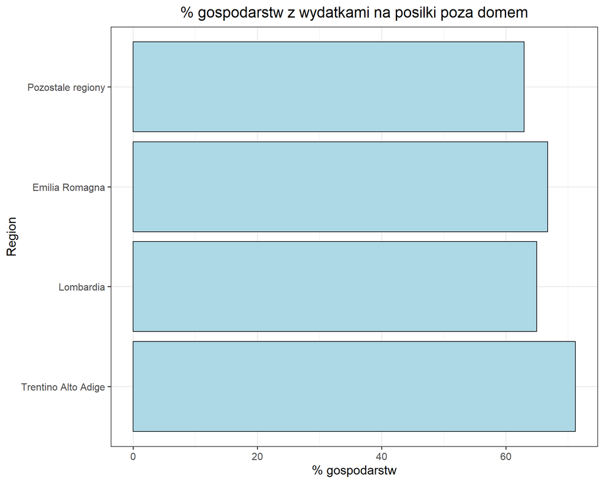

```r
biedniejsze <- danePozaDomem %>%
  filter(Regione != 3 & Regione != 4 & Regione != 8)

Lombardia <- danePozaDomem %>%
  filter(Regione == 3)

Trentino  <- danePozaDomem %>%
  filter(Regione == 4)

Emilia<- danePozaDomem %>%
  filter(Regione == 8)

LombardiaPozaDomemBez0 <- Lombardia %>%
  filter(SumaPozaDomem >0)

TrentinoPozaDomemBez0 <- Trentino %>%
  filter(SumaPozaDomem >0)

EmiliaPozaDomemBez0 <- Emilia %>%
  filter(SumaPozaDomem >0)

biedniejszePozaDomemBez0 <- biedniejsze %>%
  filter(SumaPozaDomem >0)


Lombardia_procPozaDomem <- as.numeric(count(LombardiaPozaDomemBez0)/count(Lombardia)*100)
Trentino_procPozaDomem <- as.numeric(count(TrentinoPozaDomemBez0)/count(Trentino)*100)
Emilia_procPozaDomem <- as.numeric(count(EmiliaPozaDomemBez0)/count(Emilia)*100)
biedniejsze_procPozaDomem <- as.numeric(count(biedniejszePozaDomemBez0)/count(biedniejsze)*100)

tabelaProcPozaMiastem <- c(Trentino_procPozaDomem, Lombardia_procPozaDomem, Emilia_procPozaDomem, biedniejsze_procPozaDomem)

procWydatkowPoza <- data.frame(region = c("Trentino Alto Adige", "Lombardia", "Emilia Romagna", "Pozostale regiony"), poza = c(Trentino_procPozaDomem, Lombardia_procPozaDomem, Emilia_procPozaDomem, biedniejsze_procPozaDomem))

procWydatkowPoza$region <- factor(procWydatkowPoza$region, levels = c("Trentino Alto Adige", "Lombardia", "Emilia Romagna", "Pozostale regiony"), ordered=TRUE)

ggplot(procWydatkowPoza, aes(x=poza, y=region)) +
  geom_col(fill = "lightblue", color = "black") +
  theme_bw(base_size = 15) +
  labs(title = "% gospodarstw z wydatkami na posilki poza domem", x = "% gospodarstw", y = "Region") +
  theme(plot.title = element_text(hjust = 0.5))
```

Zgodnie z przewidywaniami, wydatki na jedzenie poza domem odnotowano w okolo 60-70% gospodarstw w kazdym regionie. Najwiecej, bo troche ponad 70% gospodarstw odnotowalo takie wydatki w regionie Trentino Alto Adige. Bardziej interesujace jest jednak jak rozkladaja sie te wydatki i to czy mozna stwierdzic, ze gdzies sa znaczaco wyzsze.

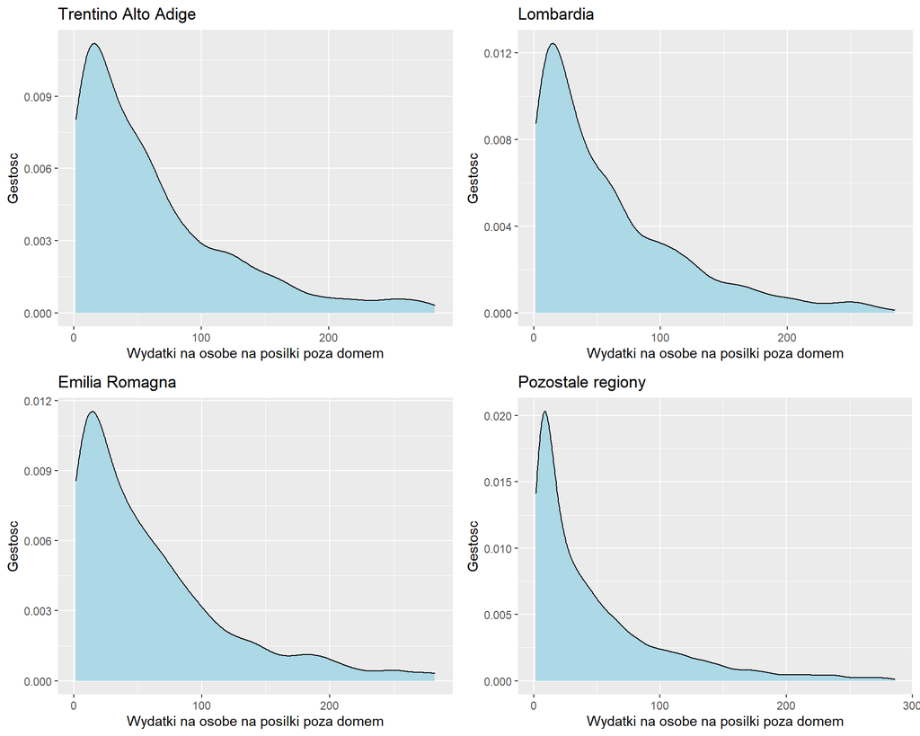

```r
danePozaDomemCzyste <- danePozaDomem %>%
  filter(SumaPozaDomem > 0)

danePozaDomemCzyste <- danePozaDomemCzyste %>%
  filter(SumaPozaDomem > quantile(SumaPozaDomem, 0.025) & SumaPozaDomem < quantile(SumaPozaDomem, 0.975))

LombardiaPozaDomemBezOdstajacych <- danePozaDomemCzyste %>%
  filter(Regione == 3)

TrentinoPozaDomemBezOdstajacych <- danePozaDomemCzyste %>%
  filter(Regione == 4)

EmiliaPozaDomemBezOdstajacych <- danePozaDomemCzyste %>%
  filter(Regione == 8)

biedniejszePozaDomemBezOdstajacych <- danePozaDomemCzyste %>%
  filter(Regione != 3 & Regione != 4 & Regione != 8)



p1 <- ggplot() +
  geom_density(TrentinoPozaDomemBezOdstajacych,mapping= aes(x=SumaPozaDomem), fill = "lightblue") +
  labs(title = "Trentino Alto Adige", x = "Wydatki na osobe na posilki poza domem", y = "Gestosc")

p2 <- ggplot() +
  geom_density(LombardiaPozaDomemBezOdstajacych,mapping= aes(x=SumaPozaDomem), fill = "lightblue")+
  labs(title = "Lombardia", x = "Wydatki na osobe na posilki poza domem", y = "Gestosc")

p3 <- ggplot() +
  geom_density(EmiliaPozaDomemBezOdstajacych,mapping= aes(x=SumaPozaDomem), fill = "lightblue")+
  labs(title = "Emilia Romagna", x = "Wydatki na osobe na posilki poza domem", y = "Gestosc")

p4 <- ggplot() +
  geom_density(biedniejszePozaDomemBezOdstajacych,mapping= aes(x=SumaPozaDomem), fill = "lightblue")+
  labs(title = "Pozostale regiony", x = "Wydatki na osobe na posilki poza domem", y = "Gestosc")

ggarrange(p1,p2,p3,p4)
```

Jak widac na powyzszych wykresach gestosci, w przypadku 3 najbogatszych regionow wykresy nie sa bardzo strome, ilosc osob wydajacych wiecej na posilki poza domem zmniejszaja sie dosc lagodnie. Zupelnie inaczej jest w przypadku pozostalej czesci Wloch, gdzie czestosc danych wydatkow spada bardzo gwalotwnie. Oznacza to, ze zdecydowanie czesciej spotyka sie rodziny, ktore wydaja malo na posilki poza domem, a wraz ze wzrostem wydatkow bardzo szybko spada ilosc takich rodzin.

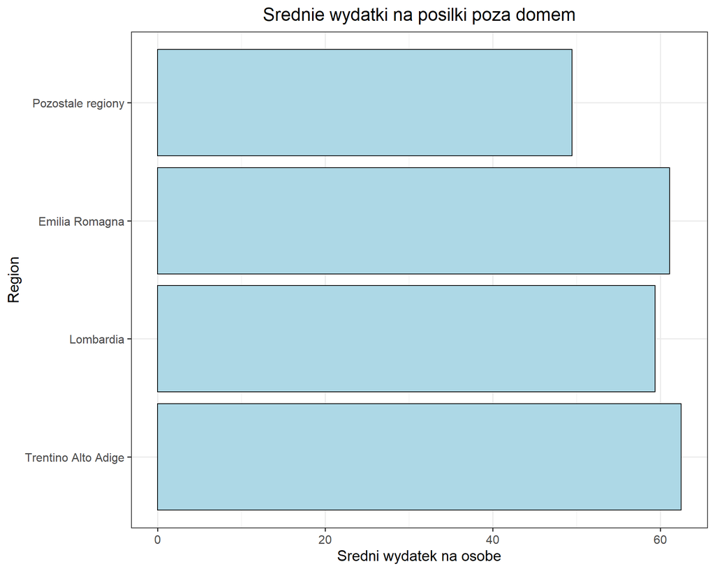

```r
tabelaSredniePozaDomem <- c(mean(TrentinoPozaDomemBezOdstajacych$SumaPozaDomem),
                            mean(LombardiaPozaDomemBezOdstajacych$SumaPozaDomem),
                            mean(EmiliaPozaDomemBezOdstajacych$SumaPozaDomem),
                            mean(biedniejszePozaDomemBezOdstajacych$SumaPozaDomem))

sredniepozadomem <- data.frame(region = c("Trentino Alto Adige", "Lombardia", "Emilia Romagna", "Pozostale regiony"), poza = tabelaSredniePozaDomem)

sredniepozadomem$region <- factor(sredniepozadomem$region, levels = c("Trentino Alto Adige", "Lombardia", "Emilia Romagna", "Pozostale regiony"), ordered=TRUE)

procWydatkowPoza <- data.frame(region = c("Trentino Alto Adige", "Lombardia", "Emilia Romagna", "Pozostale regiony"), poza = c(Trentino_procPozaDomem, Lombardia_procPozaDomem, Emilia_procPozaDomem, biedniejsze_procPozaDomem))

procWydatkowPoza$region <- factor(procWydatkowPoza$region, levels = c("Trentino Alto Adige", "Lombardia", "Emilia Romagna", "Pozostale regiony"), ordered=TRUE)

ggplot(sredniepozadomem, aes(x=poza, y=region)) +
  geom_col(fill = "lightblue", color = "black") +
  theme_bw(base_size = 15) +
  labs(title = "Srednie wydatki na posilki poza domem", x = "Sredni wydatek na osobe", y = "Region") +
  theme(plot.title = element_text(hjust = 0.5))
```

Na powyzszym wykresie widoczne sa srednie wydatki gospodarstw na posilki poza domem. W regionach Trentino Alto Adige i regionie Emilia Romagna wydatki te, sa wysokie i wynosza troche powyzej 60 euro na osobe. Nieco mniej niz 60 euro wynosza w Lombardii, natomiast w pozostalej czesci Wloch sa one znaczaco nizsze i wynosza troche ponizej 50 euro. Mozna wiec uznac, ze jesli region ma wieksze PKB per capita to mieszkancy wydaja wiecej na posilki poza domem. Okolo 10 euro jest tutaj spora roznica, gdy wezmiemy pod uwage wysokosc wydatkow wynoszaca 50-60 euro.

## Wydatki na alkohol

Regiony moga roznic sie takze pod wzgledem wydatkow na alkohol. Jesli region jest bogatszy to mieszkancy teoretycznie moga pozwolic sobie na zakup wiekszej ilosci drozszych alkoholi. Natomiast im biedniejszy tym tanszych, np piwa.

```r
dane <- dane %>%
  mutate(Alkohol = ifelse(TIPFAM==1 | TIPFAM==2 | TIPFAM==3,
                          C_1803+C_1804+C_1805,
                          (C_1803+C_1804+C_1805)/2))

Lombardia <- dane %>%
  filter(Regione == 3)

LombardiaPiwo <- Lombardia %>%
  filter(C_1804 > 0)

LombardiaProcPiwo <- as.numeric(count(LombardiaPiwo)/count(Lombardia)*100)
```

```r
tabProcPiwo <- c(TrentinoProcPiwo, LombardiaProcPiwo, EmiliaProcPiwo, biedniejszeProcPiwo)

ProcPiwo <- data.frame(region = c("Trentino Alto Adige", "Lombardia", "Emilia Romagna", "Pozostale regiony"),
                       Piwo = tabProcPiwo)

ProcPiwo$region <- factor(ProcPiwo$region, levels = c("Trentino Alto Adige", "Lombardia", "Emilia Romagna", "Pozostale regiony"), ordered=TRUE)

p2 <- ggplot(ProcPiwo, aes(x=Piwo, y=region)) +
  geom_col(fill = "aquamarine3", color = "black") +
  theme_bw(base_size = 12) +
  labs(title = "% gospodarstw z wydatkami na piwo", x = "% gospodarstw", y = "Region")
```

```r
tabProcWino <- c(TrentinoProcWino, LombardiaProcWino, EmiliaProcWino, biedniejszeProcWino)

ProcWino <- data.frame(region = c("Trentino Alto Adige", "Lombardia", "Emilia Romagna", "Pozostale regiony"),
                       Wino = tabProcWino)

ProcWino$region <- factor(ProcWino$region, levels = c("Trentino Alto Adige", "Lombardia", "Emilia Romagna", "Pozostale regiony"), ordered=TRUE)

p3 <- ggplot(ProcWino, aes(x=Wino, y=region)) +
  geom_col(fill = "aquamarine3", color = "black") +
  theme_bw(base_size = 12) +
  labs(title = "% gospodarstw z wydatkami na wino", x = "% gospodarstw", y = "Region")
```

```r
tabProcInne <- c(TrentinoProcInne, LombardiaProcInne, EmiliaProcInne, biedniejszeProcInne)

ProcInne <- data.frame(region = c("Trentino Alto Adige", "Lombardia", "Emilia Romagna", "Pozostale regiony"),
                       Inne = tabProcInne)

ProcInne$region <- factor(ProcInne$region, levels = c("Trentino Alto Adige", "Lombardia", "Emilia Romagna", "Pozostale regiony"), ordered=TRUE)

p4 <- ggplot(ProcInne, aes(x=Inne, y=region)) +
  geom_col(fill = "aquamarine3", color = "black") +
  theme_bw(base_size = 12) +
  labs(title = "% gospodarstw z wydatkami na inne alkohole", x = "% gospodarstw", y = "Region")
```

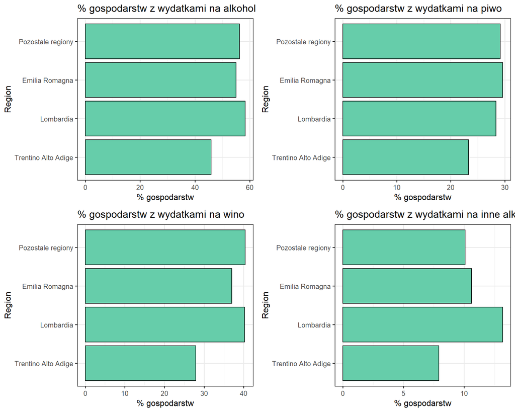

```r
tabProcAlk <- c(TrentinoProcAlk, LombardiaProcAlk, EmiliaProcAlk,
                   biedniejszeProcAlk)

ProcAlk <- data.frame(region = c("Trentino Alto Adige", "Lombardia", "Emilia Romagna", "Pozostale regiony"),
                       Alk = tabProcAlk)

ProcAlk$region <- factor(ProcAlk$region, levels = c("Trentino Alto Adige", "Lombardia", "Emilia Romagna", "Pozostale regiony"), ordered=TRUE)

p1 <- ggplot(ProcAlk, aes(x=Alk, y=region)) +
  geom_col(fill = "aquamarine3", color = "black") +
  theme_bw(base_size = 12) +
  labs(title = "% gospodarstw z wydatkami na alkohol", x = "% gospodarstw", y = "Region")

ggarrange(p1,p2,p3,p4)
```

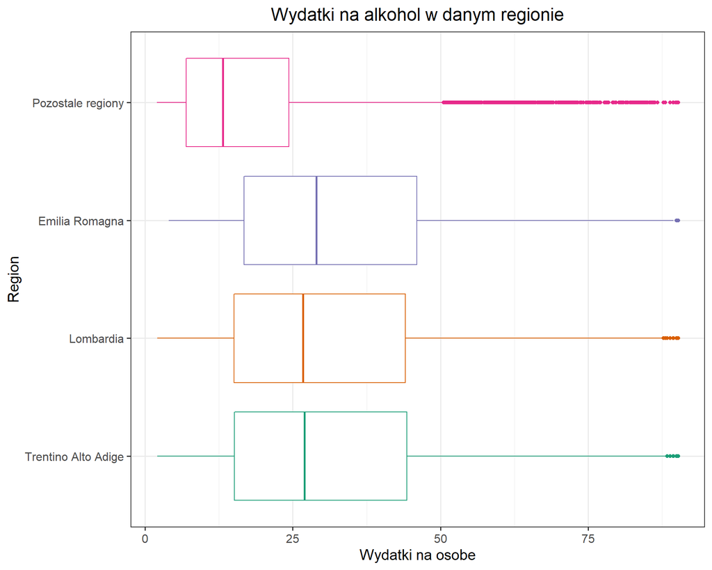

```r
daneAlkbezOdst <- daneAlkbez0 %>%
  filter(Alkohol > quantile(Alkohol, 0.02) & Alkohol < quantile(Alkohol, 0.97))

Lombardia <- daneAlkbezOdst %>%
  filter(C_1805 > 3)

Trentino <- daneAlkbezOdst %>%
  filter(C_1805 > 4)

Emilia <- daneAlkbezOdst %>%
  filter(C_1805 > 8)

biedniejsze <- daneAlkbezOdst %>%
  filter(Regione != 3 & Regione != 4 & Regione != 8)

x4 <- as.data.frame(biedniejsze$Alkohol)
x4 <- x4 %>%
  mutate(region = "Pozostale regiony")
colnames(x4) <- c("wydatkiAlkohol", "region")

x3 <- as.data.frame(Emilia$Alkohol)
x3 <- x3 %>%
  mutate(region = "Emilia Romagna")
colnames(x3) <- c("wydatkiAlkohol", "region")

x2 <- as.data.frame(Lombardia$Alkohol)
x2 <- x2 %>%
  mutate(region = "Lombardia")
colnames(x2) <- c("wydatkiAlkohol", "region")

x1 <- as.data.frame(Trentino$Alkohol)
x1 <- x1 %>%
  mutate(region = "Trentino Alto Adige")
colnames(x1) <- c("wydatkiAlkohol", "region")

danePudelkowyAlkohol <- rbind(x1, x2, x3, x4)

danePudelkowyAlkohol$region <- factor(danePudelkowyAlkohol$region, levels = c("Trentino Alto Adige", "Lombardia", "Emilia Romagna", "Pozostale regiony"), ordered=TRUE)

ggplot(danePudelkowyAlkohol, mapping = aes(x=wydatkiAlkohol, y=region)) +
  geom_boxplot(col = brewer.pal(n=4, name="Dark2")) +
  theme_bw(base_size = 15) +
  labs(title = "Wydatki na alkohol w danym regionie", x = "Wydatki na osobe", y = "Region") +
  theme(plot.title = element_text(hjust = 0.5), legend.position = "none")
```

## Wydatki na sport, rekreacje i hobby

Kolejna rzecza, ktora odroznia osoby bogatsze, od osob mniej zamoznych, to wydatki na spedzanie czasu wolnego, np sport, rekreacje i hobby. Nie jest to wydatek pierwszej potrzeby i zazwyczaj decydujemy sie na to, gdy nie mamy juz podstawowych potrzeb do spelnienia.

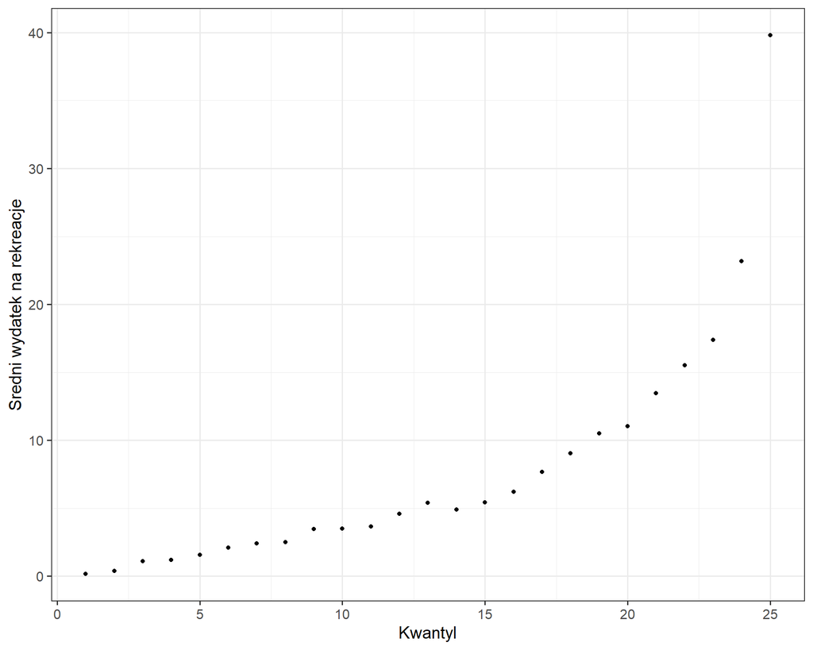

```r
dane <- dane %>%
  mutate(Rekreacja = (C_7110 + C_7201 + C_7202 + C_7111+C_7103+C_7112+C_7203+C_7113+C_7114+C_7115)/NC)

daneRek <- dane %>%
  mutate(quantile = ntile(Wydatki, 25))

daneRekbez25 <- daneRek %>%
  filter(quantile != 25)

srednieRek <- c()
for (i in 1:25) {
  sr <- daneRek %>%
    filter(quantile == i)
  srednieRek[i] <- mean(sr$Rekreacja)
}
srednieWydatki <- c()
for (i in 1:25) {
  sr <- danePozaDomem %>%
    filter(quantile == i)
  srednieWydatki[i] <- mean(sr$Wydatki)
}
kwantyle <- danePozaDomem$quantile[!duplicated(danePozaDomem$quantile)]

kwantyle <- sort(kwantyle)

ggplot() +
  geom_point(mapping=aes(x=kwantyle, y = srednieRek)) +
  labs(x="Kwantyl", y = "Sredni wydatek na rekreacje") +
  theme_bw(base_size = 15)
```

Potwierdza to bardzo dobrze powyzszy wykres. Po podzieleniu wydatkow na rekrecje na kwantyle wzgledem ogolnych wydatkow gospodarstw, widzimy, ze wraz z przejsciem do kolejnego kwantyla, czy przejsciem do wyzszych wydatkow, wydatki na rekreacje znaczaco rosna. Oznacza to, ze jest to funkcja Tornquista 3 rodzaju.

```r
m <- nls(Rekreacja ~ A*Wydatki*(Wydatki - C)/(B + Wydatki), data = daneRekbez25,
         start = list(A = 3, B = 10, C = 100))
summary(m)
```

```
##
## Formula: Rekreacja ~ A * Wydatki * (Wydatki - C)/(B + Wydatki)
##
## Parameters:
##    Estimate Std. Error t value Pr(>|t|)
## A 1.185e-02  1.345e-03   8.806   <2e-16 ***
## B 5.517e+02  4.230e+02   1.304    0.192
## C 2.755e+02  1.143e+02   2.410    0.016 *
## ---
## Signif. codes:  0 '***' 0.001 '**' 0.01 '*' 0.05 '.' 0.1 ' ' 1
##
## Residual standard error: 28.5 on 22149 degrees of freedom
##
## Number of iterations to convergence: 6
## Achieved convergence tolerance: 8.013e-06
```

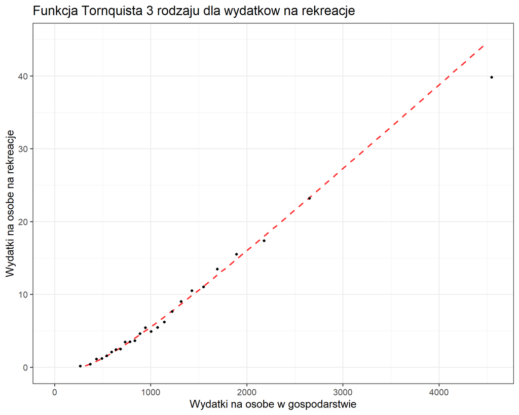

```r
A1 <- coef(m)[1]
B1 <- coef(m)[2]
C1 <- coef(m)[3]

eq = function(x){A1 * x * (x - C1)/(B1 + x)}

ggplot() +
  stat_function(fun = eq, data.frame(x=c(1,2000)), mapping=aes(x=x), col = "red", lty = 2, lwd = 1,
                alpha = 0.8) +
  geom_point(mapping=aes(srednieWydatki,srednieRek)) +
  theme_bw(base_size = 15) +
  labs(title = "Funkcja Tornquista 3 rodzaju dla wydatkow na rekreacje",
       x = "Wydatki na osobe w gospodarstwie",
       y = "Wydatki na osobe na rekreacje") +
  ylim(0,45)
```

Na powyzszym wykresie mozna zobaczyc,jak dobrze model dopasowal sie do naszych danych. Na tej podstawie mozna obliczyc elastycznosc wyadtkow na rekreacje dla badanych przez nas regionow.

```r
daneWydatki <- dane %>%
  filter(Wydatki >quantile(dane$Wydatki, 0.005) & Wydatki < quantile(dane$Wydatki, 0.995))

biedniejsze <- daneWydatki %>%
  filter(Regione != 3 & Regione != 4 & Regione != 8)

Lombardia <- daneWydatki %>%
  filter(Regione == 3)

Trentino <- daneWydatki %>%
  filter(Regione == 4)

Emilia_Romagna <- daneWydatki %>%
  filter(Regione == 8)

medTrentino <- median(Trentino$Wydatki)
ETrentino <- (medTrentino^2+2*B1*medTrentino-B1*C1)/((B1+medTrentino)*(medTrentino-C1))

medLombardia <- median(Lombardia$Wydatki)
ELombardia <- (medLombardia^2+2*B1*medLombardia-B1*C1)/((B1+medLombardia)*(medLombardia-C1))

medEmilia <- median(Emilia_Romagna$Wydatki)
EEmilia <- (medEmilia^2+2*B1*medEmilia-B1*C1)/((B1+medEmilia)*(medEmilia-C1))

medbiedniejsze <- median(biedniejsze$Wydatki)
Ebiedniejsze <- (medbiedniejsze^2+2*B1*medbiedniejsze-B1*C1)/((B1+medbiedniejsze)*(medbiedniejsze-C1))

elast <- c(ETrentino, ELombardia, EEmilia, Ebiedniejsze)
region <- c("Trentino Alto Adige", "Lombardia", "Emilia Romagna", "Pozostale regiony")

data.frame(Region = region, elastycznosc = elast)
```

```
##                Region elastycznosc
## 1 Trentino Alto Adige     1.667782
## 2           Lombardia     1.601809
## 3      Emilia Romagna     1.629008
## 4   Pozostale regiony     1.834049
```

```r
dane <- dane %>%
  mutate(Rekreacja = (C_7110 + C_7201 + C_7202 + C_7111+C_7103+C_7112+C_7203+C_7113+C_7114+C_7115)/NC)

daneRekBez0 <- dane %>%
  filter(Rekreacja > 0)

Lombardia <- dane %>%
  filter(Regione == 3)

LombardiaRekBez0 <- daneRekBez0 %>%
  filter(Regione == 3)

LombardiaProcRek <- as.numeric(count(LombardiaRekBez0)/count(Lombardia)*100)
```

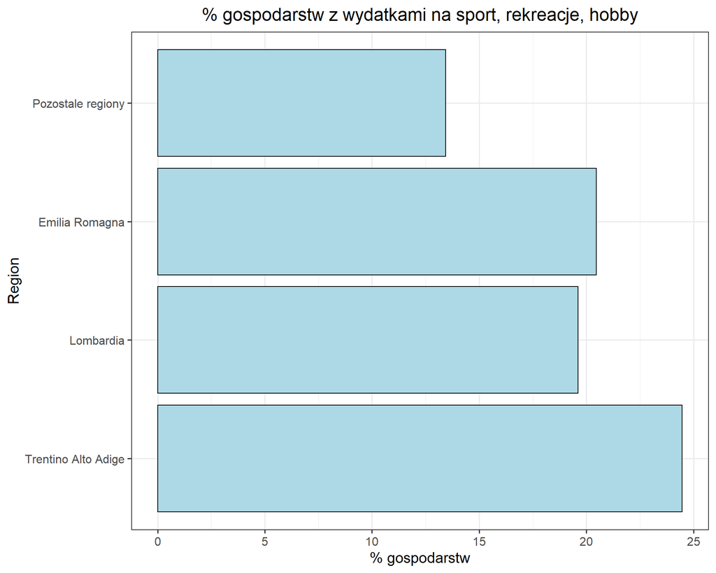

```r
tabProcRek <- c(TrentinoProcRek, LombardiaProcRek, EmiliaProcRek, biedniejszeProcRek)

ProcRek <- data.frame(region = c("Trentino Alto Adige", "Lombardia", "Emilia Romagna", "Pozostale regiony"), Rek = tabProcRek)

ProcRek$region <- factor(ProcAlk$region, levels = c("Trentino Alto Adige", "Lombardia", "Emilia Romagna", "Pozostale regiony"), ordered=TRUE)

ggplot(ProcRek, aes(x=Rek, y=region)) +
  geom_col(fill = "lightblue", color = "black") +
  theme_bw(base_size = 15) +
  labs(title = "% gospodarstw z wydatkami na sport, rekreacje, hobby", x = "% gospodarstw", y = "Region") +
  theme(plot.title = element_text(hjust = 0.5))
```

Patrzac na % gospodarstw, ktore mialy wydatki na sport, rekreacje i hobby, mozna odniesc wrazenie, ze im wyzsze PKB na mieszkanca tym wiekszy % gospodarstw pozwala sobie na takie wydatki. Prawie co 4 gospodarstwo w czasie prowadzenia badania mialo takie wydatki w regioie Trentino Alto Adige, w 2 regionach o nieco nizszym PKB na mieszkanca, czyli regionach Lombardia i Emilia Romgna takich gospodarstw bylo okolo 20%, natomiast w pozostalej czesci kraju ten procent nie przekroczyl 14.

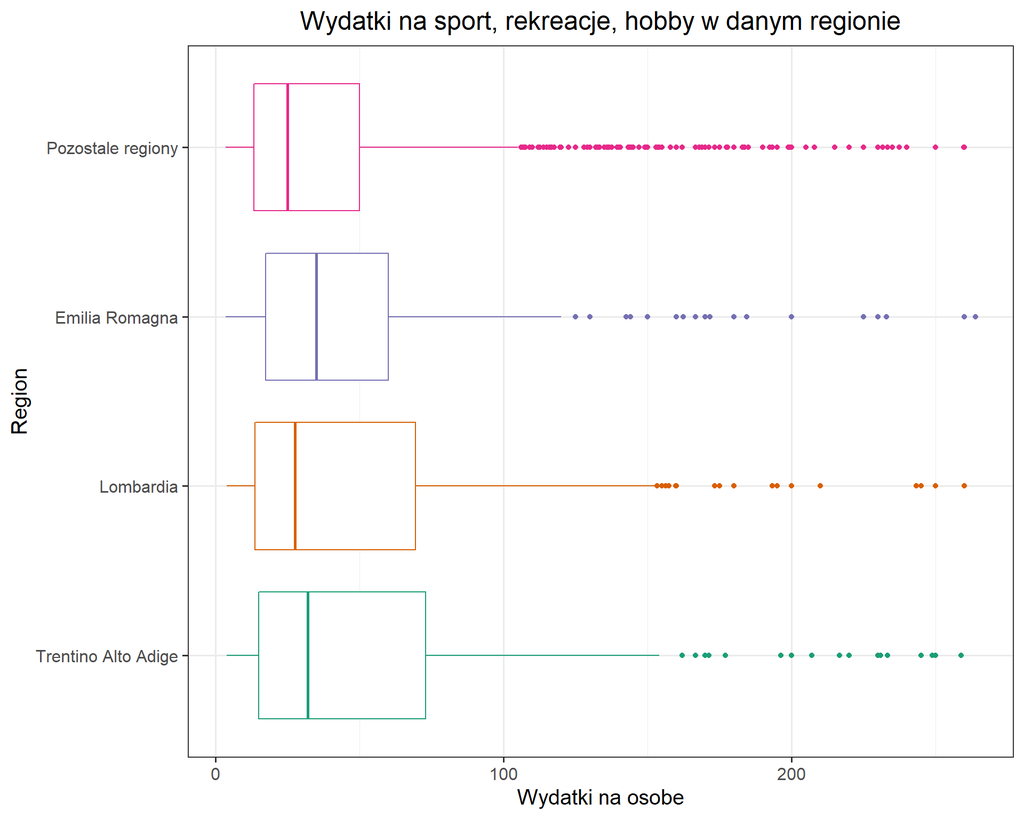

```r
LombardiaRekBezOdst <- daneRekBezOdst %>%
  filter(Regione == 3)

TrentinoRekBezOdst <- daneRekBezOdst %>%
  filter(Regione == 4)

EmiliaRekBezOdst <- daneRekBezOdst %>%
  filter(Regione == 8)

biedniejszeRekBezOdst <- daneRekBezOdst %>%
  filter(Regione != 3 & Regione != 4 & Regione != 8)

x4 <- as.data.frame(biedniejszeRekBezOdst$Rekreacja)
x4 <- x4 %>%
  mutate(region = "Pozostale regiony")
colnames(x4) <- c("wydatkiRekreacja", "region")

x3 <- as.data.frame(EmiliaRekBezOdst$Rekreacja)
x3 <- x3 %>%
  mutate(region = "Emilia Romagna")
colnames(x3) <- c("wydatkiRekreacja", "region")

x2 <- as.data.frame(LombardiaRekBezOdst$Rekreacja)
x2 <- x2 %>%
  mutate(region = "Lombardia")
colnames(x2) <- c("wydatkiRekreacja", "region")

x1 <- as.data.frame(TrentinoRekBezOdst$Rekreacja)
x1 <- x1 %>%
  mutate(region = "Trentino Alto Adige")
colnames(x1) <- c("wydatkiRekreacja", "region")

danePudelkowyRekreacja <- rbind(x1, x2, x3, x4)

danePudelkowyRekreacja$region <- factor(danePudelkowyRekreacja$region, levels = c("Trentino Alto Adige", "Lombardia", "Emilia Romagna", "Pozostale regiony"), ordered=TRUE)

ggplot(danePudelkowyRekreacja, mapping = aes(x=wydatkiRekreacja, y=region)) +
  geom_boxplot(col = brewer.pal(n=4, name="Dark2")) +
  theme_bw(base_size = 15) +
  labs(title = "Wydatki na sport, rekreacje, hobby w danym regionie", x = "Wydatki na osobe", y = "Region") +
  theme(plot.title = element_text(hjust = 0.5), legend.position = "none")
```

Zestawiajac ze soba wykresy pudelkowe wydatkow na czas wolny widac wyraznie, ze dolny i gorny kwartyl w przypadku Lombardii i Trentino Alto Adige sa oddalone od siebie zdecydowanie bardziej niz w regionie Emilia Romagna oraz pozostalej czesci Wloch. Swiadczy to o wiekszym zroznicowaniu w wydatkach w danych regionach. W regionie Emilia Romagna jest wiecej osob, ktorych wydatki na analizowane dobra sa na zblizonym poziomie. Jednak patrzac na mediane to jest ona najwyzsza w przypadku Emilii Romangi. Jest tam wiec mniej osob, ktore wydaja bardzo niewiele na swoj czas wolny. W przypadku wartosci odstajacych, wystepuja one w kazdym z regionow i sa mniej wiecej na bardzo zblizonym poziomie.

# Wnioski

- Ogolne wydatki w bogatszych regionach sa wyzsze i bardziej zroznicowane.

Z dosc duza pewnoscia mozna stwierdzic, ze w regionach o wyzszym PKB per capita wydatki gospodarstw sa wyzsze. Zostalo to dobrze zobrazowane przez mediany. Jednak ciezko stwierdzic, czy na pewno sa bardziej zrozniocowane. Dolny i gorny kwartyl w kazdym przypadku roznil sie mniej wiecej w podobnym stopniu, moze jedynie w przypadku regionu Lombardia pudelko bylo wieksze. Jednak w pozostalych przypadkach wielkosc byla bardzo zblizona.

- Mieszkancy bogatszych regionow mieszkaja w bardziej luksusowych domach.

Podobnie jak w przypadku ogolnych wydatkow, takze w przypadku luksusowych domow, to Lombardia wyroznia sie najbardziej. Praktycznie co czwarte gospodarstwo mieszka w domu o wyzszym standardzie od przecietnego. W przypadku porownania regionu Emilia Romgna oraz pozostalej czesci kraju ta roznica nie jest jednak az tak duza. Dodatkowo w Trentino Alto Adige takich domow jest zaledwie okolo 10%, czyli zdecydowanie mniej niz w pozostalej czesci kraju. Ciezko wiec uznac ta hipoteze za prawdziwa. Mozliwe jest, ze bardziej zalezy to od polozenia w danej czesci kraju, niz statusu materialnego wlascicieli.

- Mieszkancy bogatszych regionow czesciej i wiecej wydaja na kulture.

W przypadku kultury, na pewno bardzo wyroznia sie region Trentino Alto Adige, gdzie zarowno najwiecej osob ma takie wydatki, jak i mediana wydatkow jest na bardzo wysokim poziomie. Dodatkowo gorny kwartyl jest tam wysoki w porownaniu do pozostalych regionow. Patrzac na pozostale 2 regiony z wysokim PKB to, w porownaniu z reszta kraju takze dosc znaczaco sie roznia. Lombardia przede wszystkim odsetkiem osob, ktore odnotowaly takie wydatki, a Emilia Romgna mediana wydatkow, ktora jest na podobnym poziomie jak w przypadku Trentino Alto Adige. Dodatkowo, za pomoca regresji logistycznej, okazalo sie, ze to czy rodzina odnotuje wydatki na kulture zalezy od regionu zamieszkania, a takze od wydatow, a jak pokazalo badanie hipotezy pierwszej wydatki w przypadku 3 wyroznionych regionow sa wyzsze niz w pozostalej czesci kraju. Mozna wiec uznac te hipoteze za prawdziwa.

- Wydatki mieszkancow bogatszych regionow na posilki poza domem sa wyzsze.

Mimo, ze w przypadku % gospodarstw z takimi wydatkami nie bylo duzej roznicy w przypadku kazdego z regionow, to wykresy gestosci, a takze srednie wydatki dobrze uwypuklily, ze w przypadku biedniejszej czesci kraju wiekszosc osob wydaje na posilki poza domem bardzo malo. Funkcja gestosci byla tam bardzo stroma, w porownaniu do pozostalych regionow, gdzie schodzila lagodnie w dol. Dodatkowo srednie wydatki na osobe byly tam o okolo 10 euro nizsze niz w 3 wyroznionych regionach.

- Mieszkancy biedniejszych regionow czesciej decyduja sie na tansze alkohole.

W przypadku regionu Trentino Alto Adige mieszkajacy tam ludzie najrzadziej decydowali sie na zakup alkoholi. Pomijajac ten region mieszkancy 3 pozostalych czesci kraju mniej wiecej porownywalnie czesto kupowali wino i piwo, jedynie w przypadku alkoholi takich jak likiery, szampany itp. to zdecydowanie najczesciej robiono to w regionie Lombardia. Patrzac jednak na wykresy pudelkowe wydatkow na alkohol mozna uznac, ze w bogatszych regionach, jesli decydowano sie na zakup alkoholu byl on dosc drogi. Natomiast w przypadku pozostalej czesci kraju byly to bardzo czesto tanie alkohole.

- Mieszkancy bogatszych regionow chetniej podejmuja rozne aktywnosci i wydaja na nie wiecej.

Z duza pewnoscia mozna stwierdzic, ze w bogatszych regionach wieksza czesc spoleczenstwa decyduje sie na takie wydatki. Mozna takze stwierdzic, ze w bogatszych regionach wydatki te sa takze bardziej zroznicowane. Mediany wydatkow, sa jednak dosc zblizone do siebie. Ciezko, wiec potwierdzic druga czesc tej hipotezy.

# Podsumowanie

Podsumowujac, zycie mieszkancow bogatszych regionow na pewno rozni sie od tego, jakie prowadza mieszkancy pozostalej czesci kraju. Nie jest tak jednak w kazdym z aspektow. Mieszkancy z regionow o wyzszym PKB per capita notuja wyzsze laczne wydatki, chetniej i czesciej wydaja swoje oszczednosci na kulture, jedza w drozszych restauracjach, pija drozsze alkohole, a takze chetniej podejmuja sie roznych aktywnosci. Jednak nie mozna powiedziec, ze domy, w ktorych mieszkaja sa bardziej luksusowe, wcale nie pija rzadziej piwa, ani ogolnie alkoholi, a patrzac na mediany wydatkow na czas wolny nie mozna powiedziec, ze sa znaczaco wyzsze.